# TestPythonBuildVesselNetworkTutorial

This tutorial is automatically generated from the file test/python/tutorials//TestPythonBuildVesselNetworkTutorial.py.

```python
# Jupyter notebook specific imports
import matplotlib as mpl
from IPython import display
%matplotlib inline
```

## Introduction

This tutorial introduces modelling vessel networks. It will cover the following techniques:

- Building a network from a collection of nodes, segments and vessels
- Writing networks to file and visualizing it
- Building a network using a network generator

## The Test

```python
import chaste # Core Chaste functionality
import microvessel_chaste # Core Microvessel Chaste functionality
import microvessel_chaste.population.vessel # Vessel tools
import microvessel_chaste.visualization # Visualization
from microvessel_chaste.utility import * # Dimensional analysis: bring in all units for convenience
```

## Test 1 - Building a vessel network manually, writing it to file and visualizing it

First we make some nodes, which are point features from which vessels can be constructed. They are initialized with a location. Vessel network components are specialized (templated) over spatial dimension, and can be 2D or 3D. We will create a Y shaped network. Later we will learn how to build up networks in a more efficient manner. Note that we are being explicit regarding units, setting a length scale of 1 micron.

```python
file_handler = chaste.core.OutputFileHandler("Python/TestPythonBuildVesselNetworkLiteratePaper", True)
length_scale = 1.e-6*metre()
length = 100.0
n1 = microvessel_chaste.population.vessel.VesselNode3(0.0, 0.0 ,0.0, length_scale)
n2 = microvessel_chaste.population.vessel.VesselNode3(length, 0.0, 0.0, length_scale)
n3 = microvessel_chaste.population.vessel.VesselNode3(2.0 * length, length, 0.0, length_scale)
n4 = microvessel_chaste.population.vessel.VesselNode3(2.0 * length, -length, 0.0, length_scale)
```

Next we make vessel segments and vessels. Vessel segments are straight-line features which contain a vascular node at each end. Vessels can be constructed from multiple vessel segments, but in this case each vessel just has a single segment.

```python
v1 = microvessel_chaste.population.vessel.Vessel3([n1 ,n2])
v2 = microvessel_chaste.population.vessel.Vessel3([n2, n3])
v3 = microvessel_chaste.population.vessel.Vessel3([n2, n4])
```

Now we can add our vessels to a vessel network.

```python
network = microvessel_chaste.population.vessel.VesselNetwork3.Create()
network.AddVessel(v1)
network.AddVessel(v2)
network.AddVessel(v3)
network.SetSegmentRadii(10.0*length_scale)
network.SetNodeRadii(10.0*length_scale)
```

We can visualize the network

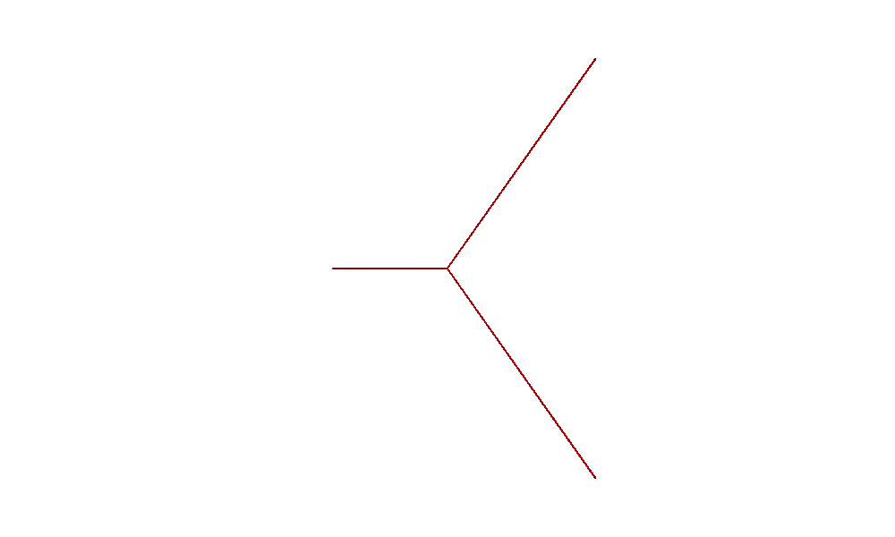

```python
scene = microvessel_chaste.visualization.MicrovesselVtkScene3()
scene.SetVesselNetwork(network)
nb_manager = microvessel_chaste.visualization.JupyterNotebookManager()
nb_manager.vtk_show(scene, height=600, width = 1000)
```

Next we write out network to file. We use the Chaste `OutputFileHandler` functionality to manage the output location. Networks are written using VTKs PolyData format, which should have a .vtp extension.

```python
writer = microvessel_chaste.population.vessel.VesselNetworkWriter3()
writer.SetVesselNetwork(network)
writer.SetFileName(file_handler.GetOutputDirectoryFullPath() + "bifurcating_network.vtp")
writer.Write()
```

We can visualize then network in Paraview.

## Test 2 - Building a vessel network with a generator

In the first test we manually built a network from its components. This is tedious. We can use a generator instead.

Create a hexagonal network in 3D space using a generator. Specify the target network width and height and the desired vessel length. The use of dimensional analysis is demonstrated by now using a fictitious 'cell width' reference length unit instead of microns.

```python
file_handler = chaste.core.OutputFileHandler("Python/TestPythonBuildVesselNetworkLiteratePaperGenerator", True)
cell_width = 25.e-6 * metre()
BaseUnits.Instance().SetReferenceLengthScale(cell_width)
target_width = 60.0 * cell_width
target_height = 30.0 * cell_width
vessel_length = 4.0 * cell_width
network_generator = microvessel_chaste.population.vessel.VesselNetworkGenerator3()
network = network_generator.GenerateHexagonalNetwork(target_width, target_height, vessel_length)
```

We can visualize the network

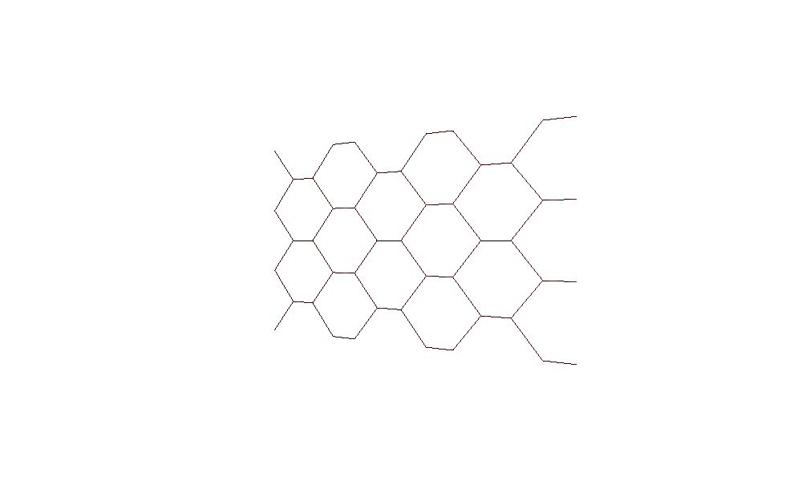

```python
scene = microvessel_chaste.visualization.MicrovesselVtkScene3()
scene.SetVesselNetwork(network)
nb_manager.vtk_show(scene, height=600, width = 1000)
```

We write the network to file as before. We want to over-ride the reference length scale so that the output is written in micron.

```python
writer = microvessel_chaste.population.vessel.VesselNetworkWriter3()
writer.SetFileName(file_handler.GetOutputDirectoryFullPath() + "hexagonal_network.vtp")
writer.SetVesselNetwork(network)
micron_length_scale = 1.e-6 * metre()
writer.SetReferenceLengthScale(micron_length_scale)
writer.Write()
```

Use a reader to read the network back in from the VTK file. Our network was written in units of micron, so we need to tell the reader this so that locations are suitably stored.

```python
network_reader = microvessel_chaste.population.vessel.VesselNetworkReader3()
network_reader.SetReferenceLengthScale(micron_length_scale)
network_reader.SetFileName(file_handler.GetOutputDirectoryFullPath() + "hexagonal_network.vtp")
network_from_file = network_reader.Read()
```

Again, we can visualize the network

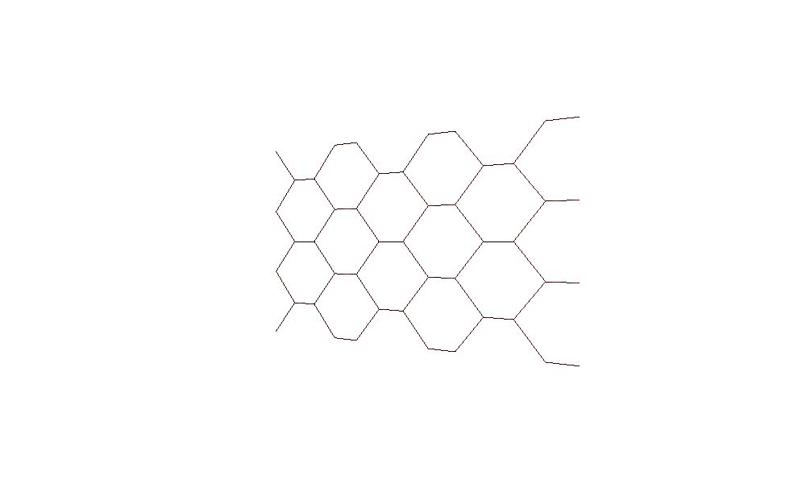

```python
scene = microvessel_chaste.visualization.MicrovesselVtkScene3()
scene.SetVesselNetwork(network)
nb_manager.vtk_show(scene, height=600, width = 1000)
```